# Bio-Optical Model

# Reflectance

**helpful links**

- https://www.l3harrisgeospatial.com/docs/spectraltoolsreferences.html
- https://oceancolor.gsfc.nasa.gov/atbd/
- https://oceancolor.gsfc.nasa.gov/atbd/rrs/
- https://oceancolor.gsfc.nasa.gov/docs/technical/#WP
- https://www.usgs.gov/core-science-systems/nli/landsat/landsat-collection-1-surface-reflectance
- http://snr.unl.edu/agmet/brdf/brdf-definition.asp
- https://dnr.wisconsin.gov/topic/lakes/clmn/remotesensing/futuredirections.html
- http://www.eo4geo.eu/training/fundaments-of-optical-remote-sensing/

Spectral-Feature Analysis and Mapping Methods in Kokaly USGS Report

### Definitions:

- **Reflectance** (dimensionless) at depth z is upwelling irradiance (flux per unit surface area) over downwelling irradiance:

$$R(\lambda, z) = \frac{E_u(\lambda, z)}{E_d(\lambda, z)}$$

- **Scalar irradiance** $(E_0)$ is the flux received by a spherical collector from all directions. This concept (how flux varies by direction) is needed to account for the portion of the signal that the sensor sees compared to all of the water-leaving irradiance.
- **Radiance** measures flux per unit area and per unit solid angle. $L(\theta, \phi)$ is the radiance in direction of zenith (vertical) angle $\theta$ and azimuth (horizontal) angle $\phi$. Integrate $L$ over the appropriate angles to get **irradiance**.
- **Remote sensing reflectance** ($sr^-1$) uses upwelling radiance instead of upwelling irradiance and is defined as:

$$R_{RS}(\theta, \phi, \lambda, 0) = \frac{L(\theta, \phi, \lambda, 0)}{E_d(\lambda, 0)}$$
A proportionality factor $Q(\theta, \phi, \lambda)$ in units of [sr] can relate $R_{RS}$ to $R$. (also called the light distribution factor, Q).

NEON measurements are non-dimensional reflectance. Get **surface remote sensing reflectance** (in [$sr^{-1}$]) dividing by pi:

$$R^w_{RS} = \frac{\rho_w}{\pi}$$

$\pi$ is the light distribution factor ($Q = \frac{E_u}{L_u}$ [$sr^{-1}$]), assuming an *isotropic light field*, where light is reflected evenly in all directions:

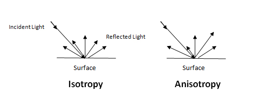

- **Remote sensing reflecatance at the surface** ($R_{rs}$) can be related to the subsurface $r_{rs}$ as (Mobley 1994, Lee et al 1998):

$$R_{rs} = \frac{\zeta \cdot r_{rs}(\lambda)}{1 - \Gamma \cdot r_{rs}(\lambda)} + R^{surf}_{rs}(\lambda)$$

- $\zeta$ is the water-to-air divergence factor, approx 0.52
- $\Gamma$ accounts for the effects of internal reflection from the water surface, approx 1.6
- $R^{surf}_{rs}(\lambda)$ is reflections at the water surface (glint)
- $R_{rs}(0+)$ is remote sensing reflectance just above water surface
- $R_{rs}(0-)$ or $r_{rs}$ is remote sensing reflectance just below water surface

The flux contained within a small solid angle spreads out to a larger solid angle so the value of emergent radiance at any angle is approx 55% of the corresponding subsurface radiance (Kutser et al 2001). Austin 1980 proposed the factor **0.544** for relating radiance just above the surface with radiance just below the surface (including an effect for internal reflection).

Kutser model (for diffuse component of remote sensing reflectance just above water surface):

Air-sea interface transfer coefficients from Lee et al 1999:

$$R_{rs}(0+) = \frac{0.52 \times R_{rs}(0-)}{1-1.7 \times R_{rs}(0-)}$$

**Gordon et al 1975, 1998** model for remote sensing reflectance just below the water surface based on Monte Carlo simulations. See Lee et al 2002 for some discussion of g1 and g2. Lee et al 2002 discuss getting total absorption.

$$r_{rs}(\lambda) = \frac{L_u(0^-,\lambda)}{E_d(0^-,\lambda)} = g_1\bigg(\frac{b_b(\lambda)}{a(\lambda) + b_b(\lambda)}\bigg) + g_2\bigg(\frac{b_b(\lambda)}{a(\lambda) + b_b(\lambda)}\bigg)^2$$
$\frac{b_b}{(a + b_b)}$ in Gordon model can be referred to as $u$.

g1 or *C* (ignoring other terms in the polynomial) depends on solar zenith angle (0.32 for sun at zenith, or 0.33 according to Prieur 1976). Kirk 1984 found *C* to be a function of the cosine of the zenith angle of refracted photons ($\mu_0$)

$$C(\mu_0) = -0.629\mu_0 + 0.975$$

Reflectance *decreases* as the solar altitude increase (solar altitude angle + solar altitude angle = 90°). For sun at zenith ($\theta_{sun} = 0$) this relationship predicts C = 0.346 (Kirk 1994).

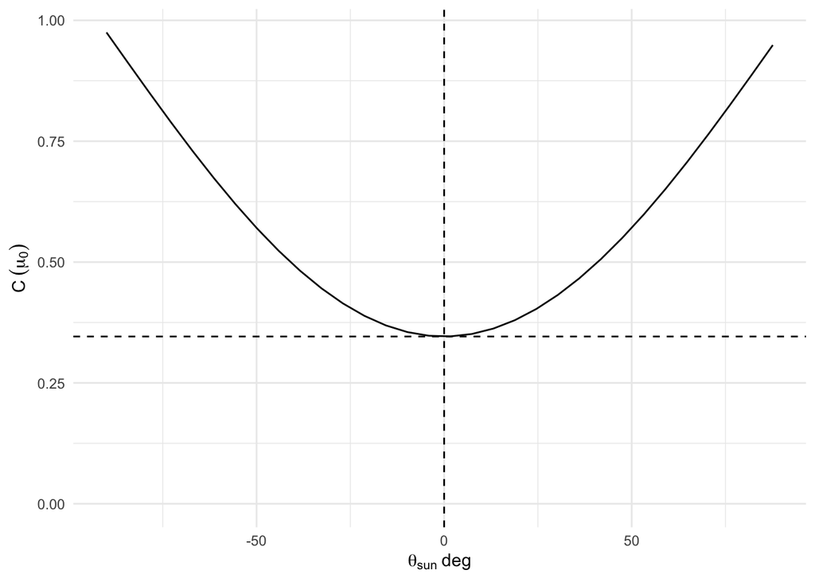

- Shape of reflectance spectra could be qualitatively compared to optical water typologies proposed by **Spyrakos et al 2018 L&O**
- Chl retrieval algorithms make use of chl absorption peaks at 442, 665, and reflectance peak around 700 nm from min sum of total absorb.

> TODO: figure out min acceptable wavelengths in Rrs data

> TODO: Extract longer wavelengths for glint removal

> TODO: BLUE 2017 (spectra S2 point in the tree canopy)

> TODO: reflectance at stream sites. optically shallow?

For optically shallow waters, would also need bottom depth and bottom albedo, and diffuse attentuation coefficient ($K$). See eg. Albert and Mobey 2003 equations

Measured reflectance spectra need to be corrected for air-water interface and normalization of $R^{+}_{rs}$ to zenith illumination and viewing geometry to get **normalized water-leaving reflectance**: $[R_w]_N$

- Full spectra goes to much longer wavelengths than of interest for water. Infrared and longer wavelengths may be useful for glint removal or other purposes
- Note that certain areas that are water vapor bands can cause spikes in the reflectance curve. For AVIRIS data, ENVI marks these 53 bands marked as “bad” (https://www.l3harrisgeospatial.com/docs/hyperspectralanalysistutorial.html): 1260 to 1560 nm (Bands 98-128), 1760 to 1960 nm (Bands 148-170)

*the 1400 nm and 1900 nm water vapor bands typically give very noisy reflectance results. These noisy values result from the low radiance values in these portions of the spectrum and can cause undesirable spikes.*

- 1050-1210 nm (for the 1135 nm water feature)
- 870-1020 nm (for the 940 nm water feature)
- 770-870 nm (for the 820 nm water feature)

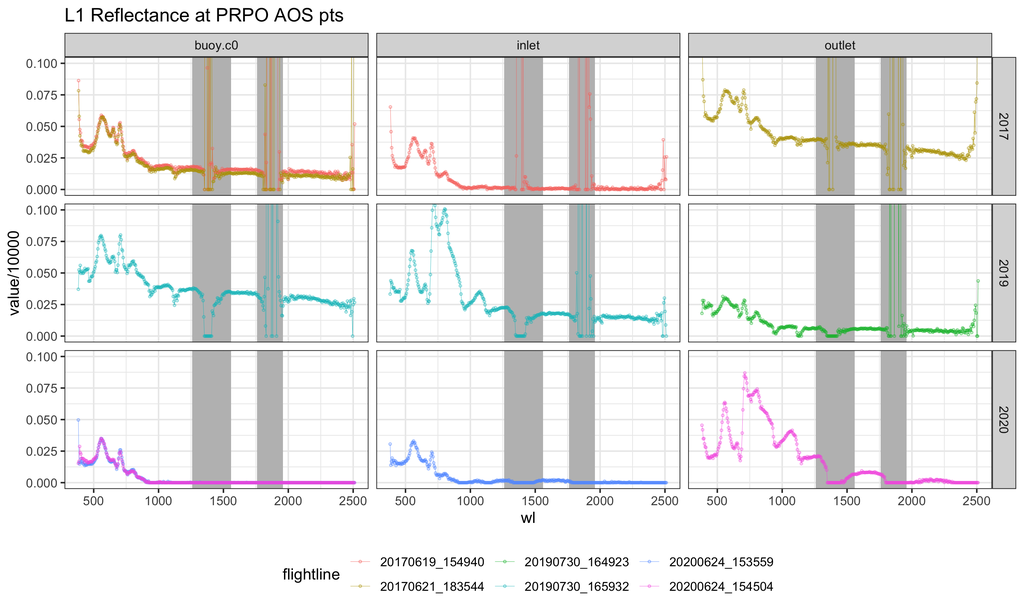

- laboratory/reference spectra are compiled from JPL, JHU, and USGS. The ECOSTRESS spectral library is a compilation of over 3400 spectra of natural and man made materials. The ECOSTRESS spectral library (formerly ASTER spectral library) is at: https://speclib.jpl.nasa.gov/
- https://ecosis.org/ Ecological Spectral Information System

## Atmospheric correction

- NEON uses ATCOR, which is proprietary but relies a lot on the value of the aerosol optical thickness which is based on observations over “dark dense vegetation”.
- Pahlevan et al 2021 review atmospheric correction for Landsat and Sentinel, comparing to validation data sets. Median errors are 20-30% for the best performing processors, which propagates to 25-75% uncertainty in derived chl a and TSS products.
- Learn more about FLAASH [here](https://www.l3harrisgeospatial.com/docs/flaash.html)

## Surface factor

> TODO: investigate using PAR and uPAR (above and below surface)

$K_d$ is an apparent optical property, diffuse attenuation under water, that depends on viewing/illumination geometry. PAR and uPAR (underwater PAR) comparison could potentially be used to separately estimate $a(\lambda)$ and $b_b(\lambda)$.

**Gordon 1989 model**:

$$K_d(\lambda) = \kappa \bigg(\frac{a(\lambda) + b_b(\lambda)}{cos\theta'_{sun}}\bigg)$$
* $\kappa \approx 1.0546$

- $\theta'_{sun}$ is sun zenith angle in water

**Lee 2005 model**:

$$K_d(\lambda) = m_0\cdot a(\lambda) + m_1(1 - m_2 e^{-m_3 \cdot a(\lambda)})(b_b(\lambda))$$
* $m_0 = 1 + 0.005 \cdot \theta_{sun}$ (sun zenith angle in air)

- $m_1 = 4.18$
- $m_2 = 0.52$
- $m_3 = 10.8$

# Sunglint

- Review of methods in **Kay et al 2009**
- In general, methods for high resolution images make no assumptions about the angle of the water surface and instead use image-based information with the assumption of no NIR water leaving radiance
- Potential for more statistical based approaches (neural networks) for high res applications
- https://towardsdatascience.com/how-to-implement-sunglint-detection-for-sentinel-2-images-in-python-using-metadata-info-155e683d50

The reflectance value of interest for aquatic purposes is the ratio of water leaving radiance to downwelling planar irradiance:

$R_{rs} = \frac{L_w(0^+)}{E_d(0^+)}$

Sensor measurement is upwelling radiance $L_u$, which includes both $L_w$ and reflected radiance from the water surface $L_r$ which has not interacted with the water column and needs to be removed.

$L_u = L_w + L_r$

The remote sensing ratio is $r_{rs} = \frac{L_u(z)}{E_d(z)}$

Based on idea that residual radiance in NIR (around 700 - 1000 nm) is from glint, because water leaving reflectance from bottom and water column ($R_w = R_b + R_c$) should be negligible. Difficult to meet this assumption (deep enough waters) in rivers.

- Hochberg et al 2003 method gets relative glint intensity from darkest and brightest pixels in NIR scaled by absolute glint intensity in each visible band. This is sensitive to outliers and requires masking land and clouds. Not good for water < 2 m where zero water leaving radiance in NIR is not valid, i.e. overcorrects shallow water imagery. Essentially models a constant NIR brightness to be removed.
- **Hedley et al 2005** assumes a linear relationship between a NIR band and each visible band to remove glint contribution. Establish a regression between NIR brightness and amount of sun glint in each visible band. First, select area with visible sun glint but deep water where underlying spectral brightness should be constant. Then for each $\lambda$ in visible, regress NIR brightness to visible band brightness. Get Minimum NIR value of image/sample, and calculate deglinted for band $i$ Rrs via slope $b_i$:

$R_i^\prime = R_i - b_i(R_{NIR} - Min_{NIR})$

Need to make sure there are no non-submerged areas. Overstreet and Legleiter use the 5% of NIR values in deep water subset to get $R_{min}$ (min NIR)

- Kutser et al 2009 assume glint at 760 nm, and the depth of the absorption feature at 760 nm is proportional to sun glint (no sun glint or oxygen absorption feature when NIR is all attenuated in water, but contaminated pixels will have feature proportional to the intensity of glint):

$D = \frac{R(739) + R(860)}{2} - R(760)$

- The upwelling radiance spectra will increase dramatically due to glint when sun is low (zenith angles are beyond 60 degrees).
- Sun glint can cause false positives in fire detection algorithms for MODIS (Giglio et al 2003). Channels at 0.65, 0.86, 2.1 (1, 2, 7) $\mu$m are used to test for false positives, along with the angle between surface-to-satellite and specular reflection directions and number of adjacent water pixels.

# In situ data

Overlaps between in situ data and flights are determined in `10-overlaps`

> TODO: Sensor to in situ regressions for chl a, turbidity, fDOM

> TODO: Use phyto taxonomy to estimate proportion of algal divisions

# Water Properties

- Use `approx` to interpolate published spectra to 1 nm.
- Assume backscattering is half of scattering coefficient

$b_{b,w} = 0.5 b_w$

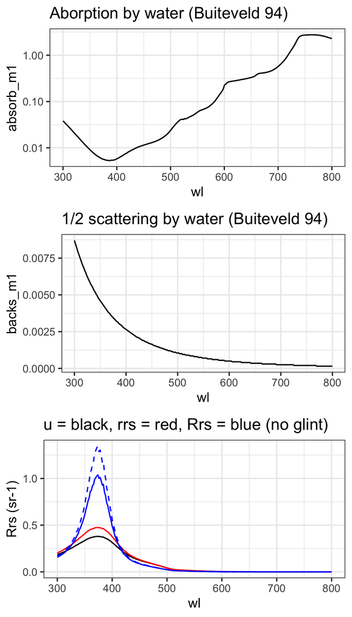

- more absorption data and links compiled [here](https://omlc.org/spectra/water/abs/)
- Pope and Fry 1997 absorption 380-700 nm at 2.5 nm res, also with standard deviations
- Comparison plot (Figure 10) to Buiteveld et al, Tam and Patel, Smith and Baker 1981, and Sogandares and Fry
- Buiteveld 1994 (absorption AND scattering 300-800 nm)
- More absorbance data in Fewell?
- Kutser et al models use Smith and Baker 1981 absorbance values
- Buiteveld et al 1994 Table 1 has absorption and scattering coefficients at 20 C, also a proposed temperature dependence (A = absorption increment due to temperature)
- Bukata CRC book table 4.1 (absorption and scattering 250-800 nm)
- Optical properties of pure water from multi-author Optics of the Ocean (Russian) 1983 and Smith and Baker
- Sogandares and Fry 1997 (Absorption and uncertainty for 10 nm increments 340 to 640 nm)
- H.Buiteveld, J.H.M. Hakvoort, and M.Donze, “The optical properties of pure water,” in Ocean Optics XII, Proc. SPIE 2258, 174-183 (1994).

> TODO: consider using temperature dependence for water spectra?

Plots also show range of reflectance data

# Absorbance

- Total absorbance is sum of water, CDOM, phytoplankton, and detritus (non-algal portion of total suspended material)

$a_{tot}(\lambda) = a_{w}(\lambda) + a_{CDOM}(\lambda) + a_{phy}(\lambda) + a_{NAP}(\lambda)$

## Phytoplankton Absorbance

- chlorophyll a is an indicator of photosynthetic plankton biomass and a proxy for phytoplankton productivity.
- quantifying chl a from remote sensing data based on relationship between chl a and the ratio of blue to green radiance
- the location of the reflectance peak in 700-720 region shifts to longer wavelengths with increasing concentration of phytoplankton. Sentinel 2 has a peak at 705, can be compared to 665-740 baseline as an indicator of chl a (**magnitude of peak**)
- **Pulliainen et al 2001** used airborne AISA and in situ data from 11 lakes in southern Finland to get chl a, 4 measurement campaigns, 450-900 nm with up to 288 channels, 1m spatial resolution.
- **Randolph et al 2008** used an ASD Fieldspec spectroradiometer along with in vitro pigment concentrations to test for rapid cyanobacteria bloom assessment, strong relationship between chl a and 665 nm band
- **Wang et al 2009** looked at chl a in Liaodong bay, China from Hyperion with exponential model between ratio of 681 to 671 nm:

$$2 \times e^{36.11 \times \frac{R681}{R671}}$$
* Gitelson et al 2011 use HICO (90m resolution) for chl a of the Azov sea:

$$chl~a = 418.88 \times \bigg((R_{684}~^{-1} - R_{700}~^{-1}) \times R_{720} \bigg) + 19.275$$

- **Awad 2014** used Artificial Neural Networks with Hyperion EO-1 (satellite, 400-2500 nm with 10nm resolution, 30m spatial resolution) data for chl a, in sea water coastal Lebanon (Mediterranean)
- **Toming et al 2016** tested band ratios on Sentinel data. Well-established algorithms for chl a concentration include: height of reflectance peak between 700 and 720
- Primary and secondary absorption maxima: 442 nm, 665 nm **Bricaud et al 1995**
- around 625 for phycocyanin (cyanobacteria) and 675 for chl a
- Peak near 700 nm (from combination of high absorbance of chl a and NIR $a_w$) commonly used to estimate chl a concentration. Magnitude of peak increases and position shifts toward longer wavelengths with increase of chl a concentration
- Some models assume that at 665 nm the total absorption is entirely from phytoplankton so $a_{t-w}$ can be used to estimate chl a concentration

Absorption spectra of phytoplankton are complex due to the mixtures of pigments and associated proteins. Derivative analysis of spectral curves helps separate absorption of chl a from accessory pigments. This helps find absorption maxima wavelength positions to attribute to certain photosynthetic pigments

chl conc (ug/L) * specific absorption (m2/mg)

Unit conversion: m2/mg * ug/L = 1/m

chla = sum of chl a AND pheophytin (Albert and Mobley 2003)

specific absorption coefficients from Gege WASI program

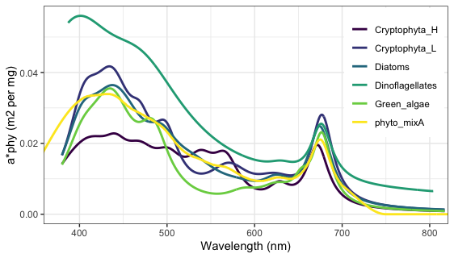

- **Bricaud et al 1995** model (used in Kutser et al models) uses power function of chl concentration to get each wavelength’s specific chl absorption coefficient:

$$a^*_{ph}(\lambda) = A(\lambda)\cdot C_{chl}^{-B(\lambda)}$$
A and B coefficients from lab measurements. This model accounts for packaging effect and means specific absorption coefficient decreases with increasing cell size and cell chl concentration.

> TODO: Correlations for band ratios

> TODO: Use taxonomy info for separate peaks?
- diatoms - **Aguirre-Gomez et al 2001** describe molar proportion of pigments as: (1/2)(3 Chla + 1 Chlc) + fucoxanthin + beta-carotene
- green algae - **Aguirre-Gomez et al 2001** describe molar proportion of pigments from Kork 1983 3:1 chla to chlb, 1:3 carotenoids to chla+b: (3)(1.6 chla + 1 chlb) + beta-carotene
- Aguirre-Gomez et al 2001 table 1 has position of peaks of pigments for diatoms, green algae, chl a, chl b, chl c1, chl c2, beta-carotene, fucoxanthin

> TODO: Separate peaks for chla vs pheophytin?

Phaeopigments are partial degradation products of chlorophyll. Absorb more strongly at 412 nm, whereas chl absorbance peaks are 443 nm and low absorbance at 412

Babin et al 2003 found that in some coastal areas (europe) high pheopigment concentrations gave rise to especially high blue-to-red ratio of phytoplankton absorption - a departure from general trend usually found for open oceanic waters for relationship between phytoplankton absorption and chlorophyll concentration

> TODO: Investigate Packaging effect: see Equation 2.39 (Bricaud et al 1995)

> TODO: Estimate at time of flight using chl a sensor data?

This data is the farthest in time from flights (> 1 month)

Model from Lee et al 1998

$a_{\phi}(\lambda) = \big[ a_0(\lambda) + a_1(\lambda) \times ln(a_{\phi}(440)) \big] a_{\phi}(440)$

$a_{\phi}(440) = 0.06 \times [chla]^{-0.65}$

chlorophyll a concentration, mg/m3

## CDOM absorbance

- Kutser et al. 1995, 1997, 1998abcd, Eloheimo et al. 1998, Kallio et al. 1998 have used airborne and ship-board optical remote sensing to look at chl a, phaeophytin-a, DOC, TOC, total phosphorus, SM, turbidity, secchi depth in turbid waters of Baltic Sea and Estonian and Finnish lakes. Overall, hard to generalize across sites and seasons.
- Kutser et al 2001 studied 12 Finnish lakes, coincident measurements included absorption spectra 350-850 nm and vertical profiles of the spectral absorption and attenuation coefficients, spectra above water surface, and AISA airborne imaging spec (7nm resolution, 1 x 1.4m spatial resolution)
- 20m resolution AVIRIS (400-2500 nm, 224 bands) collected over Pantanal in August 1995. **Galvao et al 2003** got field spectra (400-900) of 39 sites across 7 freshwater and 5 saltwater lakes
- **Toming et al 2016** found a good correlation with band ratio algorithms from Sentinel 2 data for 23 sampling points across 9 small and 2 large lakes in Estonia, sampled in August 2015. best performance for CDOM is usually green to red band ratios
- **Kutser et al 2015** showed that iron bound to carbon molecules can absorb light in similar way to CDOM. carbon to iron ratio (and ratio of colored to uncolored DOC) complicate observations of optical effects, actually could make it easier to predict lake DOC than CDOM

CDOM concentration is calculated as:

$$C_{CDOM} = \frac{c^*_f(\lambda)}{exp(-S(\lambda - \lambda_0))\cdot a^*_{CDOM}(\lambda_0)}$$
* $c^*_f(\lambda)$ is spectrometric reading at ref wavelength (380)

- Colored dissolved organic matter, also known as gelbstoff, yellow substance, or gilvin. Assumed not to scatter light because pigments are totally dissolved.
- Defined as what passes through 0.2 $\mu$m filter (traditionally 0.4)
- Absorption maxima of chromophores are in the UV, such as 180, 203, 253 nm for benzene (common aromatic ring structure in humic matter)
- tail of those peaks is approximated by:

$$a_{CDOM}(\lambda) = a_{CDOM}(\lambda_0) \times {exp}( -S \times (\lambda - \lambda_{0}))$$

mean values for $S$ are 0.016-0.017 $nm^{-1}$, sd 0.002 $nm^{-1}$, variation is due to composition. Range 0.008 - 0.042 $nm^{-1}$

CDOM concentration (Y) (proxy for DOC) can be expressed in units of absorption at $\lambda_0$, usually around 400 nm.

$$Y = a_{CDOM}(\lambda_{0})[m^{-1}]$$

- abs: absorption coefficient (m^-1)
- wl: wavelength (lambda)
- wlREF: reference wavelength commonly 380, 400, 420, 440 or 412, 443 (central wavelength of satellite bands)
- SF: slope factor **indicator of MW, source, etc**

Range for slope parameter: 275-295, 350-400 (**Helms et al 2008**, shows relation to DOM MW and photobleaching)

Gaussian decomposition method important for terrestrially influence (**Grunert et al 2018**) especially based on lignin absorbance around 276 nm

SF = 0.014 nm-1 at reference wl 440 nm in Bricaud et al 1981 but varies geographically and temporally, also depends on the wavelength range over which it is calculated, eg 400-440 nm Gege ch 2 in textbook = values range from 0.004 to 0.053 nm^-1, but in most cases in the range between 0.010/nm for humic acid dominated waters and 0.020/nm when fulvic acids prevail

Schwarz et al 2002 used gaussian model based on structure of benzene w/ peaks at 180, 203, 253 nm (after Gege 2000) and 210 and 276 nm to allow for absorption band splitting. Fit model using resol program that has been used to analyze phytoplankton spectra

Babin et al 2003 measured CDOM absorbance 350 stations in coastal waters, slope had very narrow range around 0.0176/nm, SD = 0.0020

SUVA 254 = abs[254]/DOC absREF is absorbance at reference wavelength

- Empirical relationships between $a_{CDOM}(350)$ and $a(\lambda)$ for 254, 280, 300, 330, 375, 440 in **Zhang et al 2021 STE**. Highly significant correlations based on large dataset (n = 766) of lake, river, reservoir samples.

> TODO: Estimate at time of flight using relationship with fDOM?

> TODO: Improve model with fDOM and/or SUNA data

> TODO: See if slope factor should be fit from model

## Fluorescence

- Bukata et al 2004 discuss impacts of inelastic processes

> TODO:

**Phytoplankton fluourescence**

- **Culver and Perry 1997** discuss calculations; chl a fluorescence can account for 10-40% upwelled irradiance at surface and 80% in subsurface
- flourescence emission band for CHL around 681 nm (Gower et al 1999), 680-710

Fluorescence by dissolved organic matter influences the blue part of the spectrum, with a centre wavelength ∼ 430 nm, whereas phycoerythrin fluorescence is centred around 585nm, and chlorophyll-a fluorescence at about 685nm.

- Vigneshwaran et al 2015 used hydrolight models. chl fluorescence is in red around 685-720 nm (with high productivity). Suggest that the magnitude and peak position of those wavelengths could indicate phytoplankton concentrations

**CDOM fluorescence**

## Suspended matter absorbance

- Seston = all particles aka total suspended material
- seston = detritus + phytoplankton
- inorganic component of detritus is known as tripton
- absorption differs significantly among the individual components

> TODO: model?? TODO: estimate at time of flight using sensor turbidity data?

suspended matter conc (mg/L) * specific absorption

Sometimes set to 0, e.g. for investigations at Lake Constance (Heege 2000 thesis, cited in Albert and Mobley 2003)

detrital part of suspended matter can be approximated using exponential equation like CDOM (eqn 2.44)

(SPECIFIC absorption)

$a^{*}_{d}(\lambda) = e^{-S_d \times (\lambda - \lambda_0)}$

$S_d$ values are typically less than for CDOM. Coastal waters 0.0123/nm (Babin et al 2003), 0.011/nm

In highly turbid waters, spectra could be affected by iron oxides (Babin et al 2003)

Detritus absorption can have shoulders due to the breakdown products of photosynthetic pigments (Kirk 2011). can maybe use pheophytin here?

Eqn 5.1 (Giardino chapter) similar to above but for absorbance

$a_{NAP}(\lambda) = a_{NAP}(\lambda_{ref}) \times e^{-S_{NAP}(\lambda - \lambda_{ref})}$

- reference wavelength in blue
- Shape factor of exponential curve calculated for each spectra using linear regression between wavelength and natural log of $a_{NAP}(\lambda)$
- fit between 380-730 nm, but excluding 400-480 and 620-710 ranges to avoid residual pigment absorption

# Backscattering

- Total backscattering sum of water, phytoplankton, and non-algal material

Gorden and Morel 1983 model (quasi-analytical):

$b_b(\lambda) = b_{b,w}(\lambda) + b_{b,p}(\lambda_{0})\bigg(\frac{\lambda_0}{\lambda}\bigg)^{\eta}$

$\eta$ is the Angstrom exponent and related to the particle size distribution

## Phytoplankton backscattering

> TODO: model for this?
- **Ahn et al 1992** measured the backscattering properties of 9 phytoplankters in culture for wavelengths 400-850 nm. Also measured absorption. Chl specific backscattering coefficient is very low, so they conclude that living algae have a negligible influence on backscattering in oceanic waters.

Sometimes included in the scattering and backscattering coefficients for suspended matter

## Suspended matter backscattering

- Beck et al 2019 tested 37 algorithms and 321 variants for turbidity
- Gordon et al 2009 show power law variation with wavelength, exponent between 0.4 and 1

$$b_b \approx \lambda^{-n}$$

All suspended matter or separate phytoplankton and detritus?

Scattering in natural waters is dominated by particles with diameter > 2 $\mu$m

suspended matter conc (mg/L) * specific backscattering

Constant value of specific backscattering coeffic of suspended matter as per Albert and Mobley 2003, from Lake Constance data

$b^*_{b,X} = 0.0086\ m^2g^-1$

Ratio of specific scattering to backscattering 0.019 (Heege thesis)

mg/L * m2/g = 1/m

Angstrom law approximates the wavelength dependency of scattering:

$b_{TSM}(\lambda) = b^*_{TSM} \times \left(\frac{\lambda}{\lambda_{S}}\right)^{-n}$

n is around zero in shallow and inland waters

$b^*_{TSM}$ values are around 0.5 to 1.0 m2/g at $\lambda_S$ = 555 nm

ratio of BACKscattering to total scattering is 0.2-3 % and assumed constant over visible range (tilde missing) ${b}_b = b_b \times b_{TSM}(\lambda)$

Chami et al 2005 study on scattering showed average ${b}_{bp}$ 4%, with high spectral variability (coastal waters)

Giardino chapter eqn 5.2 for backscattering from particles

$b_{b,p}(\lambda) = b_{b,p}(\lambda_{ref})\left( \frac{\lambda_{ref}}{\lambda} \right)^{-\gamma_{bb}}$

$\gamma_{bb}$ is the power law exponent of particulate backscattering coefficient, can be related to the size of particles. low values (approx 0.3) for larger particles and higher values (approx 1.7) for smaller particles. can also be an indicator of composition. High values with lower concentration compared to higher concentration TSS (0.71 for 5.95 g/m3 and 1.7 for 1.5 g/m3).

Po River lakes study (n = 152 samples) showed $a_{NAP}(440)$ ranging from 0.008 to 0.838 m^-1 $S_{NAP}$ ranged from 0.02 to 0.005 nm^-1 No relationship between S and a440, similar to boreal humic lakes and others

average $\gamma_{bb}$ was 0.68

> TODO: better model??

fit bstar angstrom, ref wavelength from model?

## Model

**Notes on Optimization:**

- ENVI has advanced spectral tools such as Spectral Feature Fitting (SFF), [Spectral Angle Mapper (SAM)](https://www.l3harrisgeospatial.com/docs/spectralanglemapper.html), and [Spectral Information Divergence (SID)](https://www.l3harrisgeospatial.com/docs/spectralinformationdivergence.html) that can measure the similarity between an unknown material and a reference material. some description how they work is [here](https://www.l3harrisgeospatial.com/docs/Whole-Pixel_Hyperspectral_Analysis_Tutorial.html)
- SAM is in the R package [RStoolbox](https://bleutner.github.io/RStoolbox/rstbx-docu/sam.html)
- *Kokaly et al USGS report* Tetracorder uses continuum removal to isolate specific absorptions and to remove the effects of changing slopes and overall reflectance levels. It compares the shapes of absorption features in the AVIRIS data with those in each reference sample of the library. A modified least-squares-fitting algorithm numerically determines the best match between the spectral features in a pixel of AVIRIS data and those in the entries of the spectral library.

Equation 4.4 in book

Thought I was being fancy with the lists but cant figure out list_merge